```python
import pandas as pd
import numpy as np
import matplotlib.pyplot as plt
import seaborn as sns
import warnings
warnings.filterwarnings('ignore')
from sklearn.experimental import enable_iterative_imputer
from sklearn.impute import IterativeImputer
from sklearn.preprocessing import OneHotEncoder
```

## Uploading the Data (Test and Train files)

```python
train_data = pd.read_csv('/content/train.csv')
train_df = train_data.copy()
pd.set_option('display.max_columns', None)
```

```python
test_data = pd.read_csv('/content/test.csv')
test_df = test_data.copy()
```

```python
train_df.head()
```

|  | galactic year | galaxy | existence expectancy index | existence expectancy at birth | Gross income per capita | Income Index | Expected years of education (galactic years) | Mean years of education (galactic years) | Intergalactic Development Index (IDI) | Education Index | Intergalactic Development Index (IDI), Rank | Population using at least basic drinking-water services (%) | Population using at least basic sanitation services (%) | Gross capital formation (% of GGP) | Population, total (millions) | Population, urban (%) | Mortality rate, under-five (per 1,000 live births) | Mortality rate, infant (per 1,000 live births) | Old age dependency ratio (old age (65 and older) per 100 creatures (ages 15-64)) | Population, ages 15–64 (millions) | Population, ages 65 and older (millions) | Life expectancy at birth, male (galactic years) | Life expectancy at birth, female (galactic years) | Population, under age 5 (millions) | Young age (0-14) dependency ratio (per 100 creatures ages 15-64) | Adolescent birth rate (births per 1,000 female creatures ages 15-19) | Total unemployment rate (female to male ratio) | Vulnerable employment (% of total employment) | Unemployment, total (% of labour force) | … |
| --- | --- | --- | --- | --- | --- | --- | --- | --- | --- | --- | --- | --- | --- | --- | --- | --- | --- | --- | --- | --- | --- | --- | --- | --- | --- | --- | --- | --- | --- | --- |
| 0 | 990025 | Large Magellanic Cloud (LMC) | 0.628657 | 63.125200 | 27109.234310 | 0.646039 | 8.240543 | NaN | NaN | NaN | NaN | NaN | NaN | 38.305483 | 681.841086 | 22.131436 | 150.259290 | 129.841789 | 12.403812 | 490.446400 | 60.121580 | 57.028183 | 69.825369 | 46.018230 | 98.216072 | 174.617899 | NaN | NaN | NaN | … |
| 1 | 990025 | Camelopardalis B | 0.818082 | 81.004994 | 30166.793960 | 0.852246 | 10.671823 | 4.742470 | 0.833624 | 0.467873 | 152.522198 | NaN | NaN | 36.255559 | 423.973089 | 89.294181 | 117.069332 | 61.822590 | 13.054898 | 560.547706 | 58.573002 | 69.873905 | 76.752305 | 40.167960 | 88.322574 | 109.892385 | NaN | NaN | NaN | … |
| 2 | 990025 | Virgo I | 0.659443 | 59.570534 | 8441.707353 | 0.499762 | 8.840316 | 5.583973 | 0.469110 | 0.363837 | 209.813266 | NaN | NaN | 18.093991 | 285.572207 | 57.491083 | 226.523760 | 134.558437 | 15.963001 | 555.012461 | 43.078497 | 59.462626 | 59.152506 | 91.093668 | 114.163995 | 230.573666 | NaN | NaN | NaN | … |
| 3 | 990025 | UGC 8651 (DDO 181) | 0.555862 | 52.333293 | NaN | NaN | NaN | NaN | NaN | NaN | NaN | NaN | NaN | NaN | 327.202247 | 47.785456 | 279.000175 | 193.228799 | 12.940991 | 766.807703 | 51.318372 | 50.535797 | 54.931369 | 92.727892 | 97.645232 | 198.971328 | NaN | NaN | NaN | … |
| 4 | 990025 | Tucana Dwarf | 0.991196 | 81.802464 | 81033.956910 | 1.131163 | 13.800672 | 13.188907 | 0.910341 | 0.918353 | 71.885345 | NaN | NaN | 34.497468 | 633.799718 | 103.562629 | 28.359587 | 51.098250 | 25.521926 | 585.434804 | 56.158054 | 85.020965 | 84.708158 | 71.493810 | 53.835875 | 61.008654 | NaN | NaN | NaN | … |

```python
test_df.head()
```

|  | galactic year | galaxy | existence expectancy index | existence expectancy at birth | Gross income per capita | Income Index | Expected years of education (galactic years) | Mean years of education (galactic years) | Intergalactic Development Index (IDI) | Education Index | Intergalactic Development Index (IDI), Rank | Population using at least basic drinking-water services (%) | Population using at least basic sanitation services (%) | Gross capital formation (% of GGP) | Population, total (millions) | Population, urban (%) | Mortality rate, under-five (per 1,000 live births) | Mortality rate, infant (per 1,000 live births) | Old age dependency ratio (old age (65 and older) per 100 creatures (ages 15-64)) | Population, ages 15–64 (millions) | Population, ages 65 and older (millions) | Life expectancy at birth, male (galactic years) | Life expectancy at birth, female (galactic years) | Population, under age 5 (millions) | Young age (0-14) dependency ratio (per 100 creatures ages 15-64) | Adolescent birth rate (births per 1,000 female creatures ages 15-19) | Total unemployment rate (female to male ratio) | Vulnerable employment (% of total employment) | Unemployment, total (% of labour force) | … |
| --- | --- | --- | --- | --- | --- | --- | --- | --- | --- | --- | --- | --- | --- | --- | --- | --- | --- | --- | --- | --- | --- | --- | --- | --- | --- | --- | --- | --- | --- | --- |
| 0 | 1007012 | KK98 77 | 0.456086 | 51.562543 | 12236.576447 | 0.593325 | 10.414164 | 10.699072 | 0.547114 | 0.556267 | 232.621842 | 105.193088 | 64.241392 | 17.418350 | NaN | NaN | NaN | NaN | NaN | NaN | NaN | NaN | NaN | NaN | NaN | NaN | NaN | NaN | NaN | … |
| 1 | 1007012 | Reticulum III | 0.529835 | 57.228262 | 3431.883825 | 0.675407 | 7.239485 | 5.311122 | 0.497688 | 0.409969 | 247.580771 | 55.730638 | 46.217440 | 33.027886 | NaN | NaN | NaN | NaN | NaN | NaN | NaN | NaN | NaN | NaN | NaN | NaN | NaN | NaN | NaN | … |
| 2 | 1008016 | Reticulum III | 0.560976 | 59.379539 | 27562.914252 | 0.594624 | 11.774890 | 5.937797 | 0.544744 | 0.486167 | 249.798771 | 58.755900 | 48.897493 | 31.613362 | NaN | NaN | NaN | NaN | NaN | NaN | NaN | NaN | NaN | NaN | NaN | NaN | NaN | NaN | NaN | … |
| 3 | 1007012 | Segue 1 | 0.565910 | 59.952390 | 20352.232905 | 0.837700 | 11.613621 | 10.067882 | 0.691641 | 0.523441 | 211.505060 | 70.176431 | 61.254104 | 34.399007 | NaN | NaN | NaN | NaN | NaN | NaN | NaN | NaN | NaN | NaN | NaN | NaN | NaN | NaN | NaN | … |
| 4 | 1013042 | Virgo I | 0.588274 | 55.428320 | 23959.704016 | 0.520579 | 10.392416 | 6.374637 | 0.530676 | 0.580418 | 234.721069 | 69.768692 | 51.316940 | 15.657091 | 1106.554194 | 64.382217 | 219.588961 | 129.974418 | 14.013421 | 474.877713 | 21.305665 | 59.144562 | 63.990109 | 80.409057 | 111.084652 | 162.451451 | 2.421466 | 126.050516 | 13.370766 | … |

```python
train_df.shape
```

```
(3865, 80)
```

```python
test_df.shape
```

```
(890, 79)
```

```python
train_df.isnull().sum()
```

|  | 0 |
| --- | --- |
| galactic year | 0 |
| galaxy | 0 |
| existence expectancy index | 1 |
| existence expectancy at birth | 1 |
| Gross income per capita | 28 |
| ... | ... |
| Adjusted net savings | 2953 |
| Creature Immunodeficiency Disease prevalence, adult (% ages 15-49), total | 2924 |
| Private galaxy capital flows (% of GGP) | 2991 |
| Gender Inequality Index (GII) | 3021 |
| y | 0 |

80 rows × 1 columns

**dtype:** int64

## Delete columns which has more than 70% missing values in both dataset (Train and Test)

```python
null_percentage = train_df.isnull().sum()/train_df.shape[0]  #calculate the ratio of missing values: null values / total values
null_cols = null_percentage[null_percentage>=0.7] #check the columns which has null value ratio over (or equal) 0.7 (70%)
null_cols.index #show these columns
```

```
Index(['Exports and imports (% of GGP)',
       'Share of seats in senate (% held by female)',
       'Natural resource depletion',
       'Mean years of education, female (galactic years)',
       'Mean years of education, male (galactic years)',
       'Expected years of education, female (galactic years)',
       'Expected years of education, male (galactic years)',
       'Estimated gross galactic income per capita, male',
       'Estimated gross galactic income per capita, female',
       'Rural population with access to electricity (%)',
       'Domestic credit provided by financial sector (% of GGP)',
       'Population with at least some secondary education, female (% ages 25 and older)',
       'Population with at least some secondary education, male (% ages 25 and older)',
       'Gross fixed capital formation (% of GGP)',
       'Remittances, inflows (% of GGP)',
       'Population with at least some secondary education (% ages 25 and older)',
       'Intergalactic inbound tourists (thousands)',
       'Gross enrolment ratio, primary (% of primary under-age population)',
       'Respiratory disease incidence (per 100,000 people)',
       'Interstellar phone subscriptions (per 100 people)',
       'Interstellar Data Net users, total (% of population)',
       'Current health expenditure (% of GGP)',
       'Intergalactic Development Index (IDI), female',
       'Intergalactic Development Index (IDI), male',
       'Gender Development Index (GDI)',
       'Intergalactic Development Index (IDI), female, Rank',
       'Intergalactic Development Index (IDI), male, Rank',
       'Adjusted net savings ',
       'Creature Immunodeficiency Disease prevalence, adult (% ages 15-49), total',
       'Private galaxy capital flows (% of GGP)',
       'Gender Inequality Index (GII)'],
      dtype='object')
```

```python
train_df = train_df.drop(columns=null_cols.index) #dropping columns which has more than 70% missing values
```

```python
test_df = test_df.drop(columns=null_cols.index) #same as above but for test dataset
```

## Impute missing values to both dataset with IterativeImputer

```python
imputer = IterativeImputer(random_state=100, max_iter=10) #setting the code to start imputing
```

```python
imputer.fit(train_df.drop('galaxy', axis=1))
```

```
IterativeImputer(random_state=100)
```

```python
df_imputed = imputer.transform(train_df.drop('galaxy', axis=1))
```

```python
df_train = pd.DataFrame(df_imputed, columns=train_df.drop('galaxy', axis=1).columns) #attaching the imputed values to the df_train

df_train['galaxy'] = train_df['galaxy'] #attaching 'galaxy' column to the updated df_train
```

```python
#putting 'galaxy' column to the 2nd place (1st index)
galaxy_col = df_train['galaxy']
df_train = df_train.drop('galaxy', axis=1)
df_train.insert(1, 'galaxy', galaxy_col)
```

```python
df_train.isnull().any().sum() #checking missing values one more time
```

```
0
```

imputing missing values for the test dataset

```python
imputer.fit(test_df.drop('galaxy', axis=1))
```

```
IterativeImputer(random_state=100)
```

```python
test_df_imputed = imputer.transform(test_df.drop('galaxy', axis=1))
```

```python
df_test = pd.DataFrame(test_df_imputed, columns=test_df.drop('galaxy', axis=1).columns)

df_test['galaxy'] = test_df['galaxy']
```

```python
galaxy_col = df_test['galaxy']
df_test = df_test.drop('galaxy', axis=1)
df_test.insert(1, 'galaxy', galaxy_col)
```

```python
df_test.isnull().any().sum()
```

```
0
```

```python
df_train['galaxy'].value_counts() #checking to see how many times a particular galaxy name has been used
```

| galaxy | count |
| --- | --- |
| Andromeda XXII[57] | 26 |
| Tucana Dwarf | 26 |
| Andromeda XXIV | 26 |
| Andromeda XIX[60] | 26 |
| Andromeda XII | 26 |
| ... | ... |
| Sagittarius Dwarf Irregular Galaxy (SagDIG) | 17 |
| Aquarius Dwarf Galaxy (DDO 210) | 17 |
| Andromeda XXI[57] | 17 |
| Pegasus Dwarf Irregular (DDO 216) | 17 |
| NGC 5253 | 1 |

181 rows × 1 columns

**dtype:** int64

```python
df_train.dtypes #checking data types of the columns to see if there is a need to cheange a data type
```

|  | 0 |
| --- | --- |
| galactic year | float64 |
| galaxy | object |
| existence expectancy index | float64 |
| existence expectancy at birth | float64 |
| Gross income per capita | float64 |
| Income Index | float64 |
| Expected years of education (galactic years) | float64 |
| Mean years of education (galactic years) | float64 |
| Intergalactic Development Index (IDI) | float64 |
| Education Index | float64 |
| Intergalactic Development Index (IDI), Rank | float64 |
| Population using at least basic drinking-water services (%) | float64 |
| Population using at least basic sanitation services (%) | float64 |
| Gross capital formation (% of GGP) | float64 |
| Population, total (millions) | float64 |
| Population, urban (%) | float64 |
| Mortality rate, under-five (per 1,000 live births) | float64 |
| Mortality rate, infant (per 1,000 live births) | float64 |
| Old age dependency ratio (old age (65 and older) per 100 creatures (ages 15-64)) | float64 |
| Population, ages 15–64 (millions) | float64 |
| Population, ages 65 and older (millions) | float64 |
| Life expectancy at birth, male (galactic years) | float64 |
| Life expectancy at birth, female (galactic years) | float64 |
| Population, under age 5 (millions) | float64 |
| Young age (0-14) dependency ratio (per 100 creatures ages 15-64) | float64 |
| Adolescent birth rate (births per 1,000 female creatures ages 15-19) | float64 |
| Total unemployment rate (female to male ratio) | float64 |
| Vulnerable employment (% of total employment) | float64 |
| Unemployment, total (% of labour force) | float64 |
| Employment in agriculture (% of total employment) | float64 |
| Labour force participation rate (% ages 15 and older) | float64 |
| Labour force participation rate (% ages 15 and older), female | float64 |
| Employment in services (% of total employment) | float64 |
| Labour force participation rate (% ages 15 and older), male | float64 |
| Employment to population ratio (% ages 15 and older) | float64 |
| Jungle area (% of total land area) | float64 |
| Share of employment in nonagriculture, female (% of total employment in nonagriculture) | float64 |
| Youth unemployment rate (female to male ratio) | float64 |
| Unemployment, youth (% ages 15–24) | float64 |
| Mortality rate, female grown up (per 1,000 people) | float64 |
| Mortality rate, male grown up (per 1,000 people) | float64 |
| Infants lacking immunization, red hot disease (% of one-galactic year-olds) | float64 |
| Infants lacking immunization, Combination Vaccine (% of one-galactic year-olds) | float64 |
| Gross galactic product (GGP) per capita | float64 |
| Gross galactic product (GGP), total | float64 |
| Outer Galaxies direct investment, net inflows (% of GGP) | float64 |
| Maternal mortality ratio (deaths per 100,000 live births) | float64 |
| Renewable energy consumption (% of total final energy consumption) | float64 |
| y | float64 |

**dtype:** object

```python
df_test.dtypes
```

|  | 0 |
| --- | --- |
| galactic year | float64 |
| galaxy | object |
| existence expectancy index | float64 |
| existence expectancy at birth | float64 |
| Gross income per capita | float64 |
| Income Index | float64 |
| Expected years of education (galactic years) | float64 |
| Mean years of education (galactic years) | float64 |
| Intergalactic Development Index (IDI) | float64 |
| Education Index | float64 |
| Intergalactic Development Index (IDI), Rank | float64 |
| Population using at least basic drinking-water services (%) | float64 |
| Population using at least basic sanitation services (%) | float64 |
| Gross capital formation (% of GGP) | float64 |
| Population, total (millions) | float64 |
| Population, urban (%) | float64 |
| Mortality rate, under-five (per 1,000 live births) | float64 |
| Mortality rate, infant (per 1,000 live births) | float64 |
| Old age dependency ratio (old age (65 and older) per 100 creatures (ages 15-64)) | float64 |
| Population, ages 15–64 (millions) | float64 |
| Population, ages 65 and older (millions) | float64 |
| Life expectancy at birth, male (galactic years) | float64 |
| Life expectancy at birth, female (galactic years) | float64 |
| Population, under age 5 (millions) | float64 |
| Young age (0-14) dependency ratio (per 100 creatures ages 15-64) | float64 |
| Adolescent birth rate (births per 1,000 female creatures ages 15-19) | float64 |
| Total unemployment rate (female to male ratio) | float64 |
| Vulnerable employment (% of total employment) | float64 |
| Unemployment, total (% of labour force) | float64 |
| Employment in agriculture (% of total employment) | float64 |
| Labour force participation rate (% ages 15 and older) | float64 |
| Labour force participation rate (% ages 15 and older), female | float64 |
| Employment in services (% of total employment) | float64 |
| Labour force participation rate (% ages 15 and older), male | float64 |
| Employment to population ratio (% ages 15 and older) | float64 |
| Jungle area (% of total land area) | float64 |
| Share of employment in nonagriculture, female (% of total employment in nonagriculture) | float64 |
| Youth unemployment rate (female to male ratio) | float64 |
| Unemployment, youth (% ages 15–24) | float64 |
| Mortality rate, female grown up (per 1,000 people) | float64 |
| Mortality rate, male grown up (per 1,000 people) | float64 |
| Infants lacking immunization, red hot disease (% of one-galactic year-olds) | float64 |
| Infants lacking immunization, Combination Vaccine (% of one-galactic year-olds) | float64 |
| Gross galactic product (GGP) per capita | float64 |
| Gross galactic product (GGP), total | float64 |
| Outer Galaxies direct investment, net inflows (% of GGP) | float64 |
| Maternal mortality ratio (deaths per 100,000 live births) | float64 |
| Renewable energy consumption (% of total final energy consumption) | float64 |

**dtype:** object

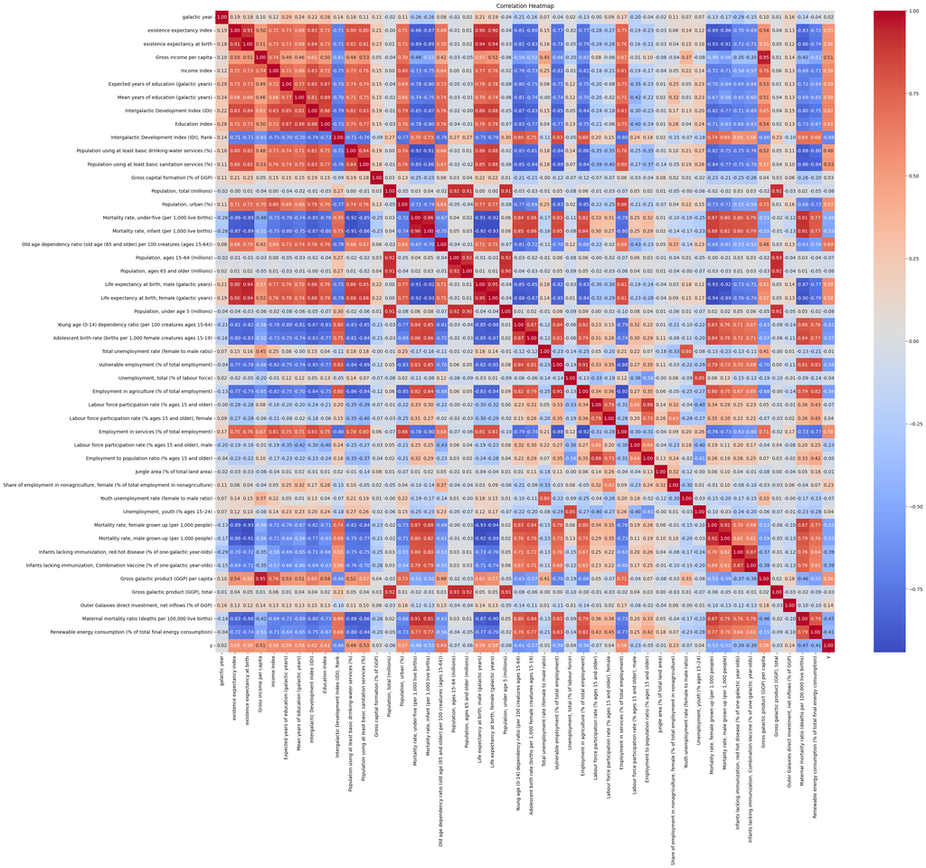

```python
#checking overall correlation between all columns
df_for_correlation = df_train.drop('galaxy', axis=1)


correlation_matrix = df_for_correlation.corr()

plt.figure(figsize=(30, 25))
sns.heatmap(correlation_matrix, annot=True, cmap='coolwarm', fmt=".2f")
plt.title('Correlation Heatmap')
plt.show()
```

## Encoding "Galaxy" column in both datasets

there is only one column which consists of strings: Galaxy. We have to change this column into numeric. Tehrefore, we will use One Hot Encoding method

```python
encoder = OneHotEncoder(handle_unknown='ignore', sparse_output=False)
encoded_galaxy = encoder.fit_transform(df_train[['galaxy']])
encoded_df = pd.DataFrame(encoded_galaxy, columns=encoder.get_feature_names_out(['galaxy']))
df_train = pd.concat([df_train, encoded_df], axis=1)
df_train = df_train.drop('galaxy', axis=1)
```

```python
y_column = df_train['y']
df_train = df_train.drop(columns=['y'])
df_train['y'] = y_column
```

```python
test_encoder = OneHotEncoder(handle_unknown='ignore', sparse_output=False)
test_encoded_galaxy = encoder.fit_transform(df_test[['galaxy']])
test_encoded_df = pd.DataFrame(test_encoded_galaxy, columns=encoder.get_feature_names_out(['galaxy']))
df_test = pd.concat([df_test, test_encoded_df], axis=1)
df_test = df_test.drop('galaxy', axis=1)
```

## As we see, after encoding "Galaxy" column, the total number of columns in Train dataset is 10 columns more than the total number of columns in Train dataset. This is becasue, there are some galaxies which are present in Train dataset but are not present in Test dataset. Therefore, I will delete these extra 9 columns.

```python
df_test.shape
```

```
(890, 219)
```

```python
df_train.shape
```

```
(3865, 229)
```

```python
columns_to_drop = list(set(df_train.columns) - set(df_test.columns)) #extracting extra columns from df_train
if 'y' in columns_to_drop:
    columns_to_drop.remove('y') #we have to keep 'y' column in df_train as we need this column to train our machine
df_train = df_train.drop(columns=columns_to_drop)
```

```python
df_train.shape #now it has only one more column. That column is "y" and this is normal
```

```
(3865, 220)
```

# Modelling

```python
from sklearn.model_selection import train_test_split
from sklearn.metrics import root_mean_squared_error

X = df_train.drop('y', axis=1)
y = df_train['y']

X_train, X_test, y_train, y_test = train_test_split(X, y, test_size=0.2, random_state=123)

print(X_train.shape, X_test.shape, y_train.shape, y_test.shape)
```

```
(3092, 219) (773, 219) (3092,) (773,)
```

### Scaling the datasets with Robust Scaler

```python
from sklearn.preprocessing import RobustScaler

scaler = RobustScaler()
X_train = scaler.fit_transform(X_train)
X_test = scaler.transform(X_test)
```

```python
scaler = RobustScaler()
df_test = scaler.fit_transform(df_test)
```

### Modelling with XGBoost method. We will use XGBRegressor

```python
import xgboost as xgb
from sklearn.metrics import mean_squared_error

model = xgb.XGBRegressor(objective='reg:squarederror', random_state=123)

model.fit(X_train, y_train)


y_pred = model.predict(X_test)
```

```python
rmse = root_mean_squared_error(y_test, y_pred)
print(f"Root Mean Squared Error: {rmse}")
```

```
Root Mean Squared Error: 0.017966651033420676
```

```python
y_pred_test = model.predict(df_test)
y_pred_test
```

```
array([0.04868083, 0.04826404, 0.04899418, 0.04920938, 0.042661  ,
       0.04301669, 0.04627457, 0.04762494, 0.05027089, 0.04691247,
       0.04766405, 0.04313454, 0.04868083, 0.04766405, 0.04242921,
       0.04716565, 0.03882044, 0.04757484, 0.04700576, 0.04918411,
       0.04689264, 0.04085737, 0.04755226, 0.03835237, 0.05334589,
       0.03859269, 0.04313325, 0.04583621, 0.04897529, 0.04792853,
       0.04812822, 0.04879374, 0.04878921, 0.06743667, 0.03881905,
       0.04886778, 0.04918411, 0.04550385, 0.04189749, 0.05186265,
       0.04918411, 0.03887015, 0.04682813, 0.04918411, 0.06671602,
       0.04579673, 0.04920938, 0.04271421, 0.04656783, 0.03516322,
       0.05034015, 0.04918411, 0.04267354, 0.04794173, 0.03946242,
       0.05006036, 0.04146305, 0.04008758, 0.0493872 , 0.04942676,
       0.04568375, 0.05114353, 0.04570535, 0.04709949, 0.04638573,
       0.04666443, 0.04812822, 0.03881654, 0.04822436, 0.0557131 ,
       0.05424692, 0.04672597, 0.04138864, 0.04348284, 0.05048265,
       0.05450333, 0.04787182, 0.04924026, 0.04587978, 0.04317881,
       0.04992   , 0.0500544 , 0.04858038, 0.03932331, 0.04001111,
       0.04253522, 0.04925338, 0.04488337, 0.03812917, 0.05547824,
       0.04869607, 0.04290309, 0.04213969, 0.05617961, 0.04969647,
       0.04832164, 0.04436996, 0.0433859 , 0.04300256, 0.04311145,
       0.04871994, 0.04835637, 0.03990204, 0.04951213, 0.05318933,
       0.04659262, 0.03942336, 0.03960674, 0.04855607, 0.04641844,
       0.0477512 , 0.04306503, 0.04285616, 0.04820203, 0.04928025,
       0.0443841 , 0.04901972, 0.06346612, 0.04323805, 0.04435223,
       0.03953212, 0.04914089, 0.04350957, 0.04323326, 0.06536293,
       0.04219216, 0.04142655, 0.04310348, 0.04595153, 0.04420945,
       0.04177748, 0.0510104 , 0.05019728, 0.03867771, 0.05175229,
       0.04154432, 0.04309649, 0.04946674, 0.04076409, 0.04221459,
       0.04813627, 0.04395065, 0.04783798, 0.04326514, 0.05004898,
       0.05025523, 0.05008439, 0.0445529 , 0.04149795, 0.04748193,
       0.04807555, 0.08382365, 0.04794173, 0.04389641, 0.04868949,
       0.04712321, 0.03911284, 0.04690365, 0.04322603, 0.0623051 ,
       0.04956502, 0.06743667, 0.04582109, 0.0393445 , 0.04371941,
       0.04794668, 0.05146019, 0.05001217, 0.05044172, 0.04395682,
       0.05040424, 0.05023546, 0.05617666, 0.04021715, 0.04045715,
       0.04395593, 0.04871127, 0.0499797 , 0.04104805, 0.04820203,
       0.04329171, 0.04305096, 0.04727048, 0.04895802, 0.0489219 ,
       0.0449139 , 0.03909447, 0.04344675, 0.04601172, 0.05102527,
       0.04075859, 0.04320757, 0.04356981, 0.053615  , 0.04612049,
       0.04862754, 0.05037759, 0.04653933, 0.05257352, 0.11055817,
```

[output cut: 124 more lines]

```
       0.1748705 , 0.23194414, 0.17679097, 0.15448095, 0.1485165 ,
       0.19808812, 0.2691281 , 0.21187963, 0.19705182, 0.17739142,
       0.21122953, 0.1878338 , 0.15313882, 0.04512979, 0.16006036,
       0.16688964, 0.27257216, 0.20525043, 0.06675313, 0.19920431,
       0.1456976 , 0.22828953, 0.21182597, 0.18769091, 0.04758364,
       0.2008847 , 0.20839442, 0.15299854, 0.06620597, 0.24028568,
       0.1279795 , 0.23738678, 0.3298477 , 0.14727063, 0.2638857 ,
       0.2482268 , 0.07869811, 0.15809286, 0.21255568, 0.16303872,
       0.19089092, 0.1379427 , 0.15761755, 0.23295899, 0.14891863,
       0.19539894, 0.07058654, 0.16616406, 0.1999738 , 0.18961929,
       0.20392838, 0.18856762, 0.12011867, 0.27368638, 0.282117  ,
       0.10602368, 0.18438861, 0.21821038, 0.22645454, 0.18323416,
       0.1750181 , 0.20265949, 0.16355017, 0.19433309, 0.18711391,
       0.05258759, 0.05258759, 0.05278008, 0.05836443, 0.05258759],
      dtype=float32)
```

## Hyperparameter Tuning

The code executed in 13 mins. And the result is the following:

Best parameters: {'learning_rate': 0.1, 'max_depth': 4, 'n_estimators': 300, 'subsample': 0.8}

```python
from sklearn.model_selection import GridSearchCV

param_grid = {
    'n_estimators': [100, 200, 300], #we gave 3 options for each 4 grids/parameters. As a result, machine will check 81 models (3*3*3*3 = 81)
    'max_depth': [4, 6, 8],
    'learning_rate': [0.01, 0.1, 0.3],
    'subsample': [0.6, 0.8, 1.0]
}


xgb = xgb.XGBRegressor(random_state=123)

grid_search = GridSearchCV(estimator=xgb, param_grid=param_grid, cv=3, scoring='neg_root_mean_squared_error', verbose=1)
grid_search.fit(X_train, y_train)

print(f"Best parameters: {grid_search.best_params_}")
```

```
Fitting 3 folds for each of 81 candidates, totalling 243 fits
Best parameters: {'learning_rate': 0.1, 'max_depth': 4, 'n_estimators': 300, 'subsample': 0.8}
```

we will apply the result of the above code to fine-tune our model

```python
import xgboost as xgb
from sklearn.metrics import mean_squared_error
final_model = xgb.XGBRegressor(
    learning_rate=0.1,
    max_depth=4,
    n_estimators=300,
    subsample=0.8,
    random_state=123
)

final_model.fit(X_train, y_train)


y_pred_tuned = final_model.predict(X_test)
```

```python
rmse = mean_squared_error(y_test, y_pred_tuned, squared=False)
print(f"RMSE: {rmse}")
```

```
RMSE: 0.017962589536556023
```

As we see, our new RMSE score is 0.01796258 after tuning our model. The previous score was 0.01796665. Fine-tuning improved the prediction power of our model.

```python
tuned_y_pred_test = final_model.predict(df_test)
tuned_y_pred_test
```

```
array([0.04796273, 0.04984559, 0.05023916, 0.05034642, 0.04334894,
       0.0448265 , 0.04760579, 0.04666518, 0.04944996, 0.04813056,
       0.04690141, 0.04304351, 0.04834247, 0.04708934, 0.04291452,
       0.04639465, 0.04040264, 0.04619361, 0.04893507, 0.04863043,
       0.04593694, 0.04235486, 0.04866182, 0.03911559, 0.0529527 ,
       0.04219339, 0.04451481, 0.04680951, 0.04877393, 0.04712943,
       0.04728844, 0.0483869 , 0.0483869 , 0.0598621 , 0.0408489 ,
       0.04851664, 0.04877393, 0.04715764, 0.04205351, 0.05245817,
       0.04871672, 0.03889753, 0.04646003, 0.048586  , 0.05871458,
       0.04624698, 0.05020291, 0.04264782, 0.04700568, 0.0409655 ,
       0.04931924, 0.04857321, 0.04164236, 0.04908912, 0.04072453,
       0.04653837, 0.04127309, 0.03954886, 0.05061525, 0.04978209,
       0.04428489, 0.0518534 , 0.04494226, 0.04713703, 0.04665319,
       0.05001153, 0.04728844, 0.03733981, 0.04904886, 0.05595358,
       0.05154806, 0.04734116, 0.04220546, 0.04496007, 0.0529527 ,
       0.05210099, 0.04885217, 0.05232774, 0.0467728 , 0.04396629,
       0.05107965, 0.0485377 , 0.04832968, 0.0385248 , 0.04233066,
       0.04269081, 0.04877393, 0.04497504, 0.03501592, 0.05313532,
       0.04995938, 0.04327632, 0.04387392, 0.0561582 , 0.0507862 ,
       0.04735805, 0.04492446, 0.04395708, 0.04439973, 0.04323827,
       0.0483869 , 0.04676925, 0.0397102 , 0.05034642, 0.05168179,
       0.04512539, 0.04156012, 0.04064001, 0.04701656, 0.04670341,
       0.05001153, 0.0477474 , 0.04209078, 0.04728844, 0.05034642,
       0.0439711 , 0.04844249, 0.05684315, 0.04268856, 0.04558678,
       0.04092278, 0.04829417, 0.04478899, 0.04236176, 0.05725352,
       0.04002247, 0.04017342, 0.04200071, 0.04954647, 0.04485624,
       0.04207407, 0.0518534 , 0.04871847, 0.03806057, 0.05107965,
       0.04238496, 0.04251238, 0.04848048, 0.03789536, 0.0439329 ,
       0.04646191, 0.04461236, 0.04608369, 0.04263224, 0.05169876,
       0.05107965, 0.05034642, 0.04766763, 0.04313337, 0.0454332 ,
       0.04931327, 0.07837675, 0.04904886, 0.04357886, 0.04741916,
       0.04548252, 0.03975027, 0.04559619, 0.04174531, 0.05922963,
       0.05000796, 0.05967417, 0.04755953, 0.03752805, 0.04324816,
       0.04723285, 0.05122827, 0.05012414, 0.05107965, 0.04475047,
       0.05170657, 0.04859931, 0.05129015, 0.04165816, 0.03807877,
       0.0449983 , 0.05034642, 0.05034642, 0.04148854, 0.04747638,
       0.04397549, 0.0443464 , 0.04778308, 0.05107965, 0.05034642,
       0.04517594, 0.04135488, 0.04520487, 0.04220091, 0.05180007,
       0.03753539, 0.04626422, 0.04419198, 0.05529771, 0.04695613,
       0.04903821, 0.05172269, 0.04752731, 0.05179122, 0.0922352 ,
```

[output cut: 124 more lines]

```
       0.18067248, 0.21704103, 0.22664653, 0.1702219 , 0.16076775,
       0.18612486, 0.27648002, 0.19825335, 0.20015582, 0.18163939,
       0.20106547, 0.19133815, 0.14745066, 0.06969713, 0.14828905,
       0.17176148, 0.27496716, 0.21403024, 0.07040983, 0.19554561,
       0.15230036, 0.20643453, 0.21971714, 0.17999639, 0.08513054,
       0.20669903, 0.20349625, 0.15760775, 0.08694367, 0.22440386,
       0.17360795, 0.23995885, 0.31407228, 0.19352348, 0.2726156 ,
       0.22828929, 0.08575105, 0.13997757, 0.21648654, 0.15649049,
       0.18582527, 0.15775894, 0.17329471, 0.23705928, 0.1598146 ,
       0.19824868, 0.0720148 , 0.16868076, 0.20510195, 0.1933774 ,
       0.17945623, 0.16235848, 0.11749291, 0.26421022, 0.3022824 ,
       0.1133735 , 0.1770263 , 0.20398197, 0.22534081, 0.17360415,
       0.16232276, 0.2013199 , 0.1622898 , 0.18724628, 0.17929663,
       0.05340876, 0.05340876, 0.05075581, 0.05762835, 0.05340876],
      dtype=float32)
```

Now, it is time to create a new dataframe with the results and export it to .csv file

```python
new_df = pd.DataFrame({
    'index': range(len(y_pred_test)),
    'y_pred_test': y_pred_test,
    'tuned_y_pred_test': tuned_y_pred_test
})


new_df.to_csv('predictions.csv', index=False)
```